# FA13: Two-Way Mixed ANOVA (Cholesterol Over Time)

by Borja, Rachelle Erika

# Introduction

This study examines whether cholesterol levels differ between two margarine brands across three time points using a two-way mixed ANOVA. Margarine type (Brand A vs. Brand B) is the between-subjects factor, and time (Before, After 4 weeks, After 8 weeks) is the within-subjects factor. The dependent variable is cholesterol level.

The null hypothesis states that there is no significant difference in cholesterol levels between the two brands of margarine over the three time points.

## Hypotheses

H₀: There is no significant interaction between margarine type and time on cholesterol levels.  
Hₐ: There is a significant interaction between margarine type and time on cholesterol levels.

# Data Preparation

```r
data <- read.csv("documents/Cholesterol_R2.csv")

data_long <- data %>%
  pivot_longer(cols = c(Before, After4weeks, After8weeks),
               names_to = "Time",
               values_to = "Cholesterol")

data_long$ID <- as.factor(data_long$ID)
data_long$Margarine <- as.factor(data_long$Margarine)
data_long$Time <- factor(data_long$Time,
                         levels = c("Before", "After4weeks", "After8weeks"))

head(data_long)
```

```
## # A tibble: 6 × 4
##   ID    Margarine Time        Cholesterol
##   <fct> <fct>     <fct>             <dbl>
## 1 1     B         Before             6.42
## 2 1     B         After4weeks        5.83
## 3 1     B         After8weeks        5.75
## 4 2     B         Before             6.76
## 5 2     B         After4weeks        6.2
## 6 2     B         After8weeks        6.13
```

# Assumption Checking

## Normality

```r
data_long %>%
  group_by(Margarine, Time) %>%
  shapiro_test(Cholesterol)
```

```
## # A tibble: 6 × 5
##   Margarine Time        variable    statistic     p
##   <fct>     <fct>       <chr>           <dbl> <dbl>
## 1 A         Before      Cholesterol     0.901 0.292
## 2 A         After4weeks Cholesterol     0.871 0.154
## 3 A         After8weeks Cholesterol     0.876 0.174
## 4 B         Before      Cholesterol     0.881 0.134
## 5 B         After4weeks Cholesterol     0.925 0.400
## 6 B         After8weeks Cholesterol     0.899 0.216
```

The Shapiro–Wilk test indicates that the assumption of normality is satisfied for all groups (p > .05).

## Homogeneity of Variance

```r
levene_test(Cholesterol ~ Margarine, data = data_long)
```

```
## # A tibble: 1 × 4
##     df1   df2 statistic       p
##   <int> <int>     <dbl>   <dbl>
## 1     1    52      10.5 0.00208
```

## Sphericity

```r
anova_test(
  data = data_long,
  dv = Cholesterol,
  wid = ID,
  within = Time,
  between = Margarine
)
```

```
## ANOVA Table (type III tests)
##
## $ANOVA
##           Effect DFn DFd       F        p p<.05   ges
## 1      Margarine   1  16   1.896 1.87e-01       0.106
## 2           Time   2  32 249.008 3.12e-20     * 0.065
## 3 Margarine:Time   2  32   4.814 1.50e-02     * 0.001
##
## $`Mauchly's Test for Sphericity`
##           Effect     W     p p<.05
## 1           Time 0.462 0.003     *
## 2 Margarine:Time 0.462 0.003     *
##
## $`Sphericity Corrections`
##           Effect  GGe     DF[GG]    p[GG] p[GG]<.05   HFe      DF[HF]    p[HF]
## 1           Time 0.65 1.3, 20.81 6.67e-14         * 0.684 1.37, 21.88 1.63e-14
## 2 Margarine:Time 0.65 1.3, 20.81 3.10e-02         * 0.684 1.37, 21.88 2.90e-02
##   p[HF]<.05
## 1         *
## 2         *
```

# Two-Way Mixed ANOVA

```r
anova_results <- ezANOVA(
  data = data_long,
  dv = Cholesterol,
  wid = ID,
  within = .(Time),
  between = .(Margarine),
  type = 3,
  detailed = TRUE
)
anova_results
```

```
## $ANOVA
##           Effect DFn DFd          SSn       SSd          F            p p<.05
## 1    (Intercept)   1  16 1.900370e+03 58.886720 516.346077 1.325525e-13     *
## 2      Margarine   1  16 6.979363e+00 58.886720   1.896350 1.874499e-01
## 3           Time   2  32 4.137657e+00  0.265865 249.008014 3.117279e-20     *
## 4 Margarine:Time   2  32 7.999056e-02  0.265865   4.813905 1.486834e-02     *
##           ges
## 1 0.969812763
## 2 0.105536938
## 3 0.065375911
## 4 0.001350449
##
## $`Mauchly's Test for Sphericity`
##           Effect         W           p p<.05
## 3           Time 0.4619574 0.003051508     *
## 4 Margarine:Time 0.4619574 0.003051508     *
##
## $`Sphericity Corrections`
##           Effect       GGe        p[GG] p[GG]<.05       HFe        p[HF]
## 3           Time 0.6501771 6.672434e-14         * 0.6838947 1.632640e-14
## 4 Margarine:Time 0.6501771 3.141480e-02         * 0.6838947 2.922041e-02
##   p[HF]<.05
## 3         *
## 4         *
```

# Post Hoc Analysis

```r
pairwise_t_test(
  data_long,
  Cholesterol ~ Time,
  paired = TRUE,
  p.adjust.method = "bonferroni"
)
```

```
## # A tibble: 3 × 10
##   .y.   group1 group2    n1    n2 statistic    df        p    p.adj p.adj.signif
## * <chr> <chr>  <chr>  <int> <int>     <dbl> <dbl>    <dbl>    <dbl> <chr>
## 1 Chol… Before After…    18    18     15.4     17 1.96e-11 5.88e-11 ****
## 2 Chol… Before After…    18    18     14.9     17 3.28e-11 9.84e-11 ****
## 3 Chol… After… After…    18    18      3.78    17 1   e- 3 4   e- 3 **
```

Post hoc comparisons using Bonferroni adjustment were conducted to examine differences across time points.

# Visualization

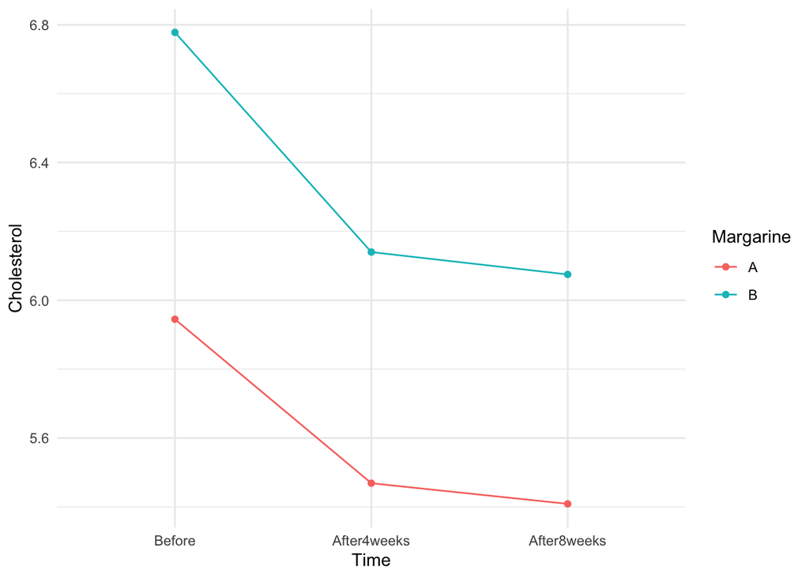

```r
ggplot(data_long, aes(x = Time, y = Cholesterol, color = Margarine, group = Margarine)) +
  stat_summary(fun = mean, geom = "line") +
  stat_summary(fun = mean, geom = "point") +
  theme_minimal()
```

# Results (in APA Format)

A two-way mixed ANOVA was conducted to examine the effects of margarine type and time on cholesterol levels.

The null hypothesis stated that there is no significant interaction between margarine type and time on cholesterol levels.

There was no significant main effect of margarine, *F*(1, 16) = 1.90, *p* = .187, indicating that overall cholesterol levels did not differ significantly between the two brands.

There was a significant interaction between margarine and time, *F*(2, 32) = 4.81, *p* = .015, indicating that the effect of margarine on cholesterol levels depends on time.

# Interpretation

The significant interaction effect indicates that the change in cholesterol levels over time varies according to the type of margarine consumed. While cholesterol levels tend to decline with time, the rate and pattern of drop differ across the two brands.

# Conclusion

This indicates that the efficacy of margarine in lowering cholesterol is dependent on the length of use.